Title: NGS Data Formats

# 학습 목표

본 실습은 sequence data format을 이해하고 각 format으로의 변환을 통해 연구자로 하여금 모든 데이터에 대해 분석을 시작할 수 있도록 한다. Format conversion을 통해 분석에 가장 필요한 기본적인 툴들의 (프로그램) 사용법을 습득하고 리눅스 환경에서의 프로그램 실행방법을 익힌다. 구체적으로 FASTA, FASTQ, SAM, BAM, VCF 파일 포맷과 활용 기법을 익히고 브라우저를 활용한 sequence alignment 상태의 visualization을 수행한다.

# 목차

1. 개요
2. FASTA
3. FASTQ 포맷
   1. Understanding FASTQ format
   2. Converting FASTQ format
   3. Trimming FASTQ format
4. BAM 포맷
   1. Understanding BAM format
   2. Converting BAM format
5. VCF 포맷
   1. VCF file compression and indexing (압축과 색인 생성)
   2. Getting allele frequency from VCF files (대립유전자 빈도 구하기)
   3. Extracting subset of samples from VCF file (원하는 샘플 데이터 추출)
   4. Comparing VCF files (비교)
6. Visualization Tools
   1. IGV viewer (Integrative Genomics Viewer)
   2. SAMtools Text Alignment Viewer
7. References

# Introduction

DNA sequence information을 담고 있는 데이터의 포맷은 FASTA, FASTQ 등 다양하지만 어떤 정보를 더 또는 덜 담고 있는지, 그리고 데이터를 어떻게 표현하고 있는지에 따라 차이가 발생한다. 포맷 변환을 통해 각 포맷의 특징을 살펴보며, 변환 시에 어떤 정보를 얻고 손실하는지 관찰할 수 있다. FASTQ로부터 FASTA로 변환하면 quality score (또는 quality value, QV)의 정보가 사라진다. Variant의 reference genome으로의 alignment를 나타낸 BAM 파일이 어떤 정보와 정렬을 표현하는지 들여다보고, 이와 함께 variant들을 일일이 나열한 VCF와 구간의 정보를 표현한 BED 파일과의 차이점도 살펴본다. 이렇게 workflow를 차근차근 살펴보면 데이터 분석을 시작할 때 어떤 단계부터 시작해야 하는지 알 수 있으며, 최종적으로 얻고자 하는 데이터와 최초의 raw data 간의 차이를 살펴보며 중간에 필요한 과정도 생각해볼 수 있다.

## 실습 준비 및 파일 확인

실습 디렉토리 `NGSFormat`으로 이동한다.

```bash
!pwd
```

```
/home/seungho/GDA/NGS/NGSFormat
```

```bash
!ls -l
```

```
합계 28
-rw-rw-r-- 1 seungho seungho 4690  7월 14 19:38 NGS_data_formats.ipynb
drwxrwxr-x 2 seungho seungho 4096  7월 14 19:22 bam
drwxrwxr-x 2 seungho seungho 4096  7월 14 19:22 fasta
drwxrwxr-x 2 seungho seungho 4096  7월 14 19:22 fastq
-rw-rw-r-- 1 seungho seungho 1760  7월 14 19:22 process.txt
drwxrwxr-x 2 seungho seungho 4096  7월 14 19:22 vcf
```

In this directory, there are four directories and they are:

- bam
- fasta
- fastq
- vcf

`process.txt` entails the process.

```bash
!cat process.txt
```

```
####################
## NGSFormat
## Sample Code
####################
## Preparation
####################
cd NGSFormat

ls

ls bam

ls fasta

ls fastq

ls vcf

####################
## FASTA
####################
cd fasta

more chr21.fa

more TP53.fasta

cd ..

####################
## FASTQ
####################
cd fastq

more illumina.fastq

fastq_to_fasta -Q 33 -i illumina.fastq -o illumina.fasta

more illumina.fasta

```

[output cut: 71 more lines]

```

cd ..

####################
## VISUALIZATION
####################
cd bam

samtools index aligned.bam

ls

igv

samtools tview aligned.bam ../fasta/chr21.fa
```

```bash
!ls bam
```

```
aligned.bam  aligned.bam.bai
```

```bash
!ls fasta
```

```
TP53.fasta  chr21.fa  chr21.fa.fai
```

```bash
!ls fastq
```

```
illumina.fastq
```

```bash
!ls vcf
```

```
dbsnp132.vcf  sample1.vcf  sample2.vcf
```

| 파일 이름 | 설명 |
| --- | --- |
| bam/aligned.bam | chr21 영역에 대한 sequence alignment를 수행한 결과 파일 |
| fasta/TP53.fasta | Pubmed에서 내려받은 TP53 단백질 서열 |
| fasta/chr21.fa | chr21의 Human Reference Genome |
| illumina.fastq | Illumina 기계에서 sequencing한 데이터 파일 |
| process.txt | 본 실습에서 수행하는 명령어가 담긴 파일 |
| vcf/dbsnp132.vcf | chr21영역에 대한 dbSNP 132버전의 정보가 담긴 파일 |
| vcf/sample1.vcf, vcf/sample2.vcf | 두 명에 대한 변이 정보를 저장한 파일 |

# FASTA format

## Understanding FASTA format

FASTA (pronounced "Fast-A") is the most basic format to express a sequence, whether it be a nucleotide or amino acid sequence. FASTA format은 sequence info를 저장하므로 reference로 많이 사용되고 있다. 사람의 유전체, 유전자 서열 등을 저장하는데 많이 사용되며 `.fasta` 혹은 `.fa`의 확장자를 갖는다.

```bash
cd fasta
pwd
head -20 chr21.fa
```

```
/home/seungho/GDA/NGS/NGSFormat/fasta
>chr21
NNNNNNNNNNNNNNNNNNNNNNNNNNNNNNNNNNNNNNNNNNNNNNNNNN
NNNNNNNNNNNNNNNNNNNNNNNNNNNNNNNNNNNNNNNNNNNNNNNNNN
NNNNNNNNNNNNNNNNNNNNNNNNNNNNNNNNNNNNNNNNNNNNNNNNNN
NNNNNNNNNNNNNNNNNNNNNNNNNNNNNNNNNNNNNNNNNNNNNNNNNN
NNNNNNNNNNNNNNNNNNNNNNNNNNNNNNNNNNNNNNNNNNNNNNNNNN
NNNNNNNNNNNNNNNNNNNNNNNNNNNNNNNNNNNNNNNNNNNNNNNNNN
NNNNNNNNNNNNNNNNNNNNNNNNNNNNNNNNNNNNNNNNNNNNNNNNNN
NNNNNNNNNNNNNNNNNNNNNNNNNNNNNNNNNNNNNNNNNNNNNNNNNN
NNNNNNNNNNNNNNNNNNNNNNNNNNNNNNNNNNNNNNNNNNNNNNNNNN
NNNNNNNNNNNNNNNNNNNNNNNNNNNNNNNNNNNNNNNNNNNNNNNNNN
NNNNNNNNNNNNNNNNNNNNNNNNNNNNNNNNNNNNNNNNNNNNNNNNNN
NNNNNNNNNNNNNNNNNNNNNNNNNNNNNNNNNNNNNNNNNNNNNNNNNN
NNNNNNNNNNNNNNNNNNNNNNNNNNNNNNNNNNNNNNNNNNNNNNNNNN
NNNNNNNNNNNNNNNNNNNNNNNNNNNNNNNNNNNNNNNNNNNNNNNNNN
NNNNNNNNNNNNNNNNNNNNNNNNNNNNNNNNNNNNNNNNNNNNNNNNNN
NNNNNNNNNNNNNNNNNNNNNNNNNNNNNNNNNNNNNNNNNNNNNNNNNN
NNNNNNNNNNNNNNNNNNNNNNNNNNNNNNNNNNNNNNNNNNNNNNNNNN
NNNNNNNNNNNNNNNNNNNNNNNNNNNNNNNNNNNNNNNNNNNNNNNNNN
NNNNNNNNNNNNNNNNNNNNNNNNNNNNNNNNNNNNNNNNNNNNNNNNNN
```

```bash
%%bash
cd fasta
cat TP53.fasta
```

```
>gi|369762890|gb|AEX20383.1| tumor suppressor TP53 [Homo sapiens]
MDDLMLSPDDIEQWFTEDPGPDEAPRMPEAAPPVAPAPAAPTPAAPAPAPSWPLSSSVPSQKTYQGSYGF
RLGFLHSGTAKSVTCTYSPALNKMFCQLAKTCPVQLWVDSTPPPGTRVRAMAIYKQSQHMTEVVRRCPHH
ERCSDSDGLAPPQHLIRVEGNLRVEYLDDRNTFRHSVVVPYEPPEVGSDCTTIHYNYMCNSSCMGGMNRR
PILTIITLEDSSGNLLGRNSFEVRVCACPGRDRRTEEENLRKKGEPHHELPPGSTKRALPNNTSSSPQPK
KKPLDGEYFTLQIRGRERFEMFRELNEALELKDAQAGKEPGGSRAHSSHLKSKKGQSTSRHKKLMFKTEG
PDSD
```

# FASTQ format

## Understanding FASTQ format

FASTA 이외의 실험을 통해 얻은 서열 정보는 FASTQ (Fast-Q)파일에 저장한다. 실험에서 얻어진 base call의 quality를 표현하기 위함이며 아직 sequence alignment가 되지 않기 때문에 기계적으로 붙인 서열의 annotation information도 담겨 있다.

```bash
cd fastq
head -30 illumina.fastq
```

```
@SDUS-BRUNO-015B_775:2:1305:6936:145736/1
GGGAAGATTGCTTGAGCCTGGGAGGTCAGGCTGCAGTGAGCTGTGATCGTGCCACCGAACTCCAGTGTGGGCAACAGAATCAGACCATGTCTCAAAAAAA
+
HHHGHHHHGHHHHHHHHHGHHHHHHCHHHHGHHHHDFGHGHHGHHHHHHFHFHHHHHBHGHHHHHFHFHFDCGFGHHHHGHHHHHFHHHEHGGHHHHHHH
@SDUS-BRUNO-015B_775:2:2305:2412:15652/1
AATAACCAATCTCAAATTTTTTTTTAAAGGACTAAGTGAATTAGTAATTAAGTACAAAAAGCTTGGGACAGTGTCTGAGCTCCAGGGTGAGTTGTCAGTA
+
HHHHHHHEHHGGGGG@HHHHHHHHHDGHHGCHEFFHDGFHHHHGEHHHHFHFFHHHGGGHHFHHHHHHHDFCFFFGGFFDHHHDGGGFGBGCGGGG?GEF
@SDUS-BRUNO-015B_775:2:1205:12644:131667/1
AAGCTTGGGACAGTGTCTGAGCTCCAGGGTGAGTTGTCAGTATTGTTATTATTGGTATGCTAATCAAAGCCAACCTAGAATTTGTATTACTTTTCCAATC
+
HHHHHHGHHFGFG9GCEDEEE?DEEFFFE*EDE<ECCEDEABFFFCFBGFFFEDF>F<FEFHHEHFHHFFGDHHHHFGFHGHHHFGCGGFDGHHHHFBHH
@SDUS-BRUNO-015B_775:3:2105:16459:178372/1
GGTGGTGCACACCTGTGGCCCCAGCTACTCAGGAGGCTGAGGTGGGAAGATTGCTTGAGCCTGGGAGGTCAGGCTGCAGTGAGCTGTGATCGTGCCACCG
+
DDADD>E@DEFEFFFDFGGEGDGGGFDGGGGGDFGGGEGDGGBGGGGGGFGDGFGGGEGDFBFFFBEE0DEEEE6EE8EBFFFECG>GBFBDDDDGGEFG
@SDUS-BRUNO-015B_775:2:1304:4849:11383/1
TGGTGGTGCACACCTGTGGCCCCAGCTACTCAGGAGGCTGAGGTGGGAAGATTGCTTGAGCCTGGGAGGTCAGGCTGCAGTGAGCTGTGATCGTGCCACC
+
GHGHFHHDEHGGGGGHHHEEHHGHGFGEHGGHGHHBEGGGEGGEGGGDGGGGFHHHEHFEEBEGGGFFG<DDAD=CFEDEGGHHEEDBEFHGEHHHEFGE
@SDUS-BRUNO-015B_775:4:1104:19831:140045/1
TTAAAGGACTAAGTGAATTAGTAATTAAGTACAAAAAGCTTGGGACAGTGTCTGAGCTCCAGGGTGAGTTGTCAGTATTGTTATTATTGGTATGCTAATC
+
HGHHGHHHGHHDEHFHGHHDGEFEGFFFEEHHHHHGGDGHFDEFDFFFAFFGGEEG.GGGEFEE?DEE@EE?EDEGFEGGHHHFGDGDG@?EEEEHGHHG
@SDUS-BRUNO-015B_775:4:2304:4319:88393/1
CATGGTGGTGCACACCTGTGGCCCCAGCTACTCAGGAGGCTGAGGTGGGAAGATTGCTTGAGCCTGGGAGGTCAGGCTGCAGTGAGCTGTGATCGTGCCA
+
GGGGEEHHEHHHHGHHHHHHHHHHHHHHGHHGHHHFHFHHHHHHH@HHHFHHFHHHFHEGHHHHHHHGHFEEHHGHHHHGHEHHHHHHHFHHFHHHHHGH
@SDUS-BRUNO-015B_775:4:1104:21091:87466/1
AAGTGAATTAGTAATTAAGTACAAAAAGCTTGGGACAGTGTCTGAGCTCCAGGGAGAGTTGTCAGTATTGTTATTATTGGTATGCTAATCAAAGCCAACC
```

첫 행에는 automatically assigned 식별자가 붙어있다 `@identifier`형태.

- `@SDUS-BRUNO-015B_775:2:1305:6936:145736/1`
- `@장비의 고유한 번호:lane의 번호:x좌표:y좌표:multiplexing indexing:paired-end`
- `.fastq` 또는 `.fq` 확장자

두번째 행에는 실험에서 얻은 서열 정보가,

세번째 행에는 +와 optional 하게 다시 identifier가 있으며

네번째 행에는 quality score가 담겨 있다.

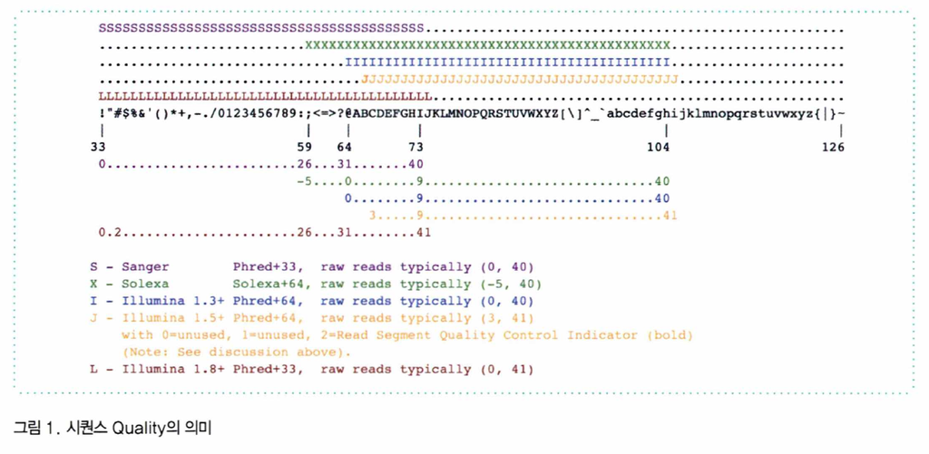

이게 Phred score ( $Q = -\log_{10}P$ )만 있는 것이 아니고, 회사와 장비 별로 서로 다른 quality score를 채택하기도 한다. 위 그림에서 S, X, I, J, L은 특정 institute과 실험 장비에 따라 quality score를 나타내는 범위를 나타내는 것으로 실험에서 얻은 서열 데이터의 질을 표현한다.

## FASTQ 포맷 변환하기

FASTQ 포맷으로 얻은 데이터를 quality 값을 제거하고 서열 정보만 보고 싶으면? FASTA format으로 변환하면 된다.

```bash
cd fastq
fastq_to_fasta -Q 33 -i illumina.fastq -o illumina.fasta
```

여기서는 실행 안된다. 왜냐면 `fastx_toolkit version 0.0.14` 를 설치해야 fastq_to_fasta를 사용할 수 있기 때문이다. `which fastq_to_fasta`를 써보면 서버에서는 `/opt/` 아래 디렉토리에 설치되어 있다.

`-Q 33` 옵션은 이 파일이 Illumina fastq파일로 quality score가 Phred+33을 따르기 때문에 쓴다.

`-i xxxx.fastq` 옵션은 인풋 파일의 이름

`-o xxxx.fasta` 옵션은 아웃풋 파일의 이름

## FASTQ 서열 잘라내기 (trimming)

장비와 실험의 한계 때문에 read가 길어질 수록 데이터의 질은 떨어질 수 밖에 없다. 따라서 낮은 질의 데이터를 제거하고 서열 정렬 (sequence alignment)를 수행하는 것이 좋은 선택이 될 수도 있다. Read는 **앞** 혹은 **뒤쪽**에서 지정해 준 길이만큼 잘라내어 사용할 수 있으며 이때 중요한 것은 모든 서열과 질을 나타낸 문자열의 길이가 모두 동일해야한다는 것이다. 이처럼 alignment의 양 끝 부분을 잘라내는 data processing 과정을 trimming이라 한다.

Trimming을 직접 실습해보자.

```bash
cd fastq
fastx_trimmer -Q 33 -l 50 -i illumina.fastq -o trimmed.fastq
cat trimmed.fastq | more
```

```
fastx_trimmer: 명령을 찾을 수 없습니다
cat: trimmed.fastq: 그런 파일이나 디렉터리가 없습니다
```

`-l` 옵션은 뒤에서 부터 50개를 잘라내겠다는 뜻이다. `trimmed.fastq`를 `cat trimmed.fastq | less` command로 확인해보면 quality score 또한 뒤 쪽 50개가 날아간 것을 볼 수 있다.

반대로 앞에서 trimming 할 때에는 `-f` 옵션을 사용한다.

즉 100개의 염기 중 20~80 번째만 남기고 싶다면 `-f20` `-l20`으로 입력하면 된다.

특정한 score 이상의 quality를 갖는 염기만 남기고 그 이외 부분에서 trim을 수행해주는 프로그램도 있지만, 그런 경우 모든 read의 길이가 달라지기 때문에 paired-end 데이터에서 서열을 정렬하기가 어려워진다. 예전에는 read의 길이가 달라지면 이후 프로그램에서 input으로 받지도 ㅇ낳았지만 요새는 read의 길이가 달라지더라도 프로그램이 문제없이 실행된다. 하지만 read 중에는 너무 짧은 read 혹인 paired-end read 구성을 실패하여 singleton으로 align되는 read 들이 많아져서 결과적으로 효과적이라고 보기는 어렵다. 따라서 되도록이면 read 길이를 맞춰주는 편이 좋음.

# BAM format

## BAM format 이해하기

BAM은 SAM (Sequence Alignment/MAP) 포맷의 binary version 포맷이다. 사람도 읽을 수 있는 SAM과 다르게 컴퓨터만 알아볼 수 있는 저장 형태로 연산의 수행 속도가 향상되고 파일 크기가 작아지는 장점이 있다.

```bash
cd ..
cd bam
```

```bash
pwd
```

```
/home/seungho/GDA/NGS/NGSFormat/bam
```

```bash
head -5 aligned.bam
```

[output not shown]

```bash
samtools view -h aligned.bam > aligned.sam
head -50 aligned.sam
```

```
@HD	VN:1.0	GO:none	SO:coordinate
@SQ	SN:chr21	LN:48129895
@RG	ID:ex	PL:illumina	PU:ex	LB:ex	SM:ex
@PG	ID:GATK TableRecalibration	VN:1.3-21-gcb284ee	CL:default_read_group=null default_platform=null force_read_group=null force_platform=null window_size_nqs=5 homopolymer_nback=7 exception_if_no_tile=false solid_recal_mode=SET_Q_ZERO solid_nocall_strategy=THROW_EXCEPTION recal_file=pre_recal_data.cs…
@PG	ID:bwa	PN:bwa	VN:0.5.9-r16
@PG	ID:GATK IndelRealigner	VN:1.3-21-gcb284ee	CL:knownAlleles=[] LODThresholdForCleaning=5.0 consensusDeterminationModel=USE_READS entropyThreshold=0.15 maxReadsInMemory=150000 maxIsizeForMovement=3000 maxPositionalMoveAllowed=200 maxConsensuses=30 maxReadsForConsensuses=120 maxReadsForRealignment=2…
SDUS-BRUNO-015B_775:2:1308:1344:108111	81	chr21	9497415	25	100M	=	45436115	35938600	AAGTTGAATCCCTAGATAGACCAATAACAGGCTATGAAATTGAGGCAATAATTAATAGCCTACCAACCAAAAAAAGTCCAGGACCAGACAGATTCACAGC	?>@B>CA>BC@D@?B@A@BA@CAA?AAC@A@B@>?CA@?B>A@@?CA??B?A@E>=AABC@@BBB@BCD@BBCAB?;BD@@??@A@E?B?@>A@A>B?B>	X0:i:1	X1:i:0	…
SDUS-BRUNO-015B_775:2:1106:9117:173634	161	chr21	9595179	37	100M	=	45411579	35816500	GTAGCTACACCCACCATGCCTTTGAGGGTTGAGTGCTACCACTTGGCCCCTGCCACTTCAGGATCCAATTATTCCAAATTGTATTTAACTTTTGTAACTG	=;<?;?B<<1A@?=9=<=:?3::68C-.6=<@56@??=>>=???2'+5(4=C=B>@@>C?D9C?=A=A?@?@A>=BCB?@9@=9=<=A:A?>@===A?=6	X0:i:1	X1:i:0…
SDUS-BRUNO-015B_775:4:2208:4615:154306	161	chr21	9647444	25	100M	=	45677373	36030026	GGAGGCTGAGGCAGGAGAACGGCTTGAACCCGGGAGGTGGAGGTTGCAGTGAGCCAAGATTGCGCCATTGCACTCCAGCCTGGGCGACAGAGTGAGACTC	>CA>B7@>=(%493.?@<>:&99<<;:+:<C;C8@A8%7211%@6>>A@>?BC7B>AA1@ADB;AD??BC9=@@>C>?@A>6<7:83?<8?>;=?::5==	X0:i:1	X1:i:0…
SDUS-BRUNO-015B_775:2:2307:14497:114310	177	chr21	9696694	37	100M	=	46262676	36565982	GGACTGGGTTCAGAGGGCTTCTGGATAACACTTCCTGGAAGGTAGTGCGCCCCTCCCCACATGCCGGGCCCCACATTTATTTCTGAACTTTTTGCAATGT	######@:>4??A@H?3B?B>.>?9/;=;:>>,@?=@B:=??=@A<@4?>',7%8?>1??@6==5<>:$/%4?>97@7?C6??=A@;:AB>=<=4<<;<A	X0:i:1	X1:i:…
SDUS-BRUNO-015B_775:3:2102:4832:112349	177	chr21	9961220	37	64M1I35M	=	45875076	35913857	ATTTATCCTGCCTCAGCCTCCCAAGTAGCTGGGATTACAGACAACTGCCACCACATCCGGCTAATTTTTTTTTATTTTTAGTAGAGACAGGGTTTTACCA	5?<?>A?C<D>@1@G@BGCB;BBA@@?BB@BCH>DA?@B@B;?B>=>A@>AB@@?A(;<B@AC=BBB@B?AA@?B?DB@A?AACBCACAD@>BA@=@?C>	X0:i:1	X1…
SDUS-BRUNO-015B_775:2:1304:17225:145079	65	chr21	10024788	0	100M	=	45586732	35561944	TATTTGATTCTTCTCTCTTTTCTTCTTTATTAGTCTTGCTAGTGGTCTATCAATTTTGTTGATCTTTTCAAAAAACCAGCTCCTGGATTCATTGAGTTTT	?>>AABC=BABACABAB@BABC@AB@BB@>CACABCBBCB>C@CDACB@>DBB>BCAA>DEB>ACAABB@@D@CD?B=CCABCBCCC?BB@>BBCA@@?=	X0:i:2	X1:i:2…
SDUS-BRUNO-015B_775:4:2202:6273:68988	81	chr21	10096053	37	100M	=	45974830	35878677	TGAGGATTTCTGGGGAAGTGTTAGGGATTAGAGACAGGATAAGGTACAAAACTAGGTAAATTAGAGAGTGAATAGATTGGAACATATGTAGTATGATTGA	=A@@A?ACDC@BABBBB@@@C?BE@C@DABBABABACB??DBB@AABBDB?DABBA?AA@AAABCBA@ADA@;AC?A@BBAAA?@?@A?B@@?@B>B?A?	X0:i:1	X1:i:0	…
SDUS-BRUNO-015B_775:3:1104:17232:80111	177	chr21	10731858	25	100M	=	45432054	34700196	CTACAAAATGAGTGTTTCCAAACTACTACATCAAAAGAAAGTTTTAACACTGTGAGATGAATGCACACATCACAAAGAAGTTTATCAGACTGCTTTTGTC	@>?BBAA=ABA??AGBBEDA@AE@>C?BC@CFBABBABCCABBBBBBDBDA@>CAA??FA?@BA<B=B?DB@CBABACB@BD@=DAAB@B@@BBBB??B>	X0:i:1	X1:i:…
SDUS-BRUNO-015B_775:3:2105:5624:88623	129	chr21	10768426	0	100M	=	45420719	34652293	GTTCTTCCATTTGTTTGTATCCTCTTTTATTTCATTGAGCAGTGGTTTGTAGTTCTCCTTGAAGAGGTCCTTCACATCCCTTGTAAGTTGGATTCCTAGG	>@@B?BBA?=ACCBBCCAA?BBBAAABC?>CAB@?BADDA?B=CFACBB>@CACBABBAADDBCCDBAE?ABC?@@@CACABC=?BDBDE9A=A@B?>AA	X0:i:4	X1:i:24…
SDUS-BRUNO-015B_775:4:2304:3841:162909	129	chr21	10887536	37	100M	=	45326750	34439214	TCCCTACACTCCAATTTAGCTGCAGTTCTCTTGGCCAGTCCTATGAAATACATCCATGGCCTAACGACTTCTCACCACTACTACCACTCATGCTGACAGC	@B@@?;@@=@A>@=?A;;*<AC>>A;==?=>B@CAA@CBBA@>;AB?B9=<C?AB>>A=ABB=:7/<:A8<@.=?=;+?=?BB>BEB<A?8=B>@5@>@6	X0:i:1	X1:i:…
SDUS-BRUNO-015B_775:2:2105:1355:3496	177	chr21	11027767	37	100M	=	45540897	34513130	ATTATTTGAGGATTACAGGAAAGCTGACAAAAGGCTTTGTGAAAGCTTTGCTTTAAATAATCTGAATAATAAATACTTGAAATGGAAATAATTTATCTGA	<?;5?696=8.;92;98EAB@ABA=>AD3C>@@AECCA?BCA@@@B?E@=>:B9>A9@A=B6=B@@;@6=AA>AACD?B;?<<@>>@>>3>?B9<AB=B@	X0:i:1	X1:i:0	…
SDUS-BRUNO-015B_775:3:1206:7428:171390	163	chr21	14730787	29	100M	=	14730998	312	AAGAACTCAACACCTTTTACAATAGCTGCAAAAAACGAACAAAAATAAAACAACAAAACTTAGGAATATACCTAGCAAAGGAATCAAAAGACCTCTACAG	=B?>=<A>A7+%)*2;9653<B@A@AACA?8'<@4=9AAA@@/?=:5B@?C@BB@AA@B>B;A<>;=;=0ACB><=>2@A=-A?AE<@ADC@9;A>>=;#	X0:i:1	X1:i:0	MD:…
SDUS-BRUNO-015B_775:3:1206:7428:171390	83	chr21	14730998	29	76M2D24M	=	14730787	-312	GGTAGGCAGAAGTGGTAGTGAGCCAAAAACCCCCCATTGCACGCCCACCTGAGCAAAAAGGGCGAAACCCCCTCTGAAAAAAAAAAAAAAAAACAAGAAA	############################################################################??>??BAA@BBAAC?B@AB@B@?B	MD:Z:13T14T1A…
SDUS-BRUNO-015B_775:3:2205:1587:29718	117	chr21	15181689	0	*	=	15181689	0	GGGGCAGAGATGTCAATGACCAAAGATCTTTCCTTTGCACCCCAGCCTGGGGGAAAGAAAAAGACCCCAACTAAAAAAAAAAAAAAAAGAAAAGAATTGA	#########################################################################??B@BCB@CDB@@D?*@BBAC@>?>@>	RG:Z:ex	OQ:Z:###########…
SDUS-BRUNO-015B_775:3:2205:1587:29718	185	chr21	15181689	0	100M	=	15181689	0	TTTTGTAGTTTTAGTAGAGACGGGGTTTCACCATGTGAGCCAGGATGGTCTCGATCTCCGGACCTTGTGATCCCCCCGCCTCGGCCTCCCAAAGTGCTGG	###########################################################################?9<9A?<=:@C;=@?AAB;@AC?A>	X0:i:5	X1:i:0	MD:Z:7T…
SDUS-BRUNO-015B_775:4:1104:8775:77987	81	chr21	15365144	0	100M	=	45344951	29979707	CAGTTTGTTATAATTTCTGTTCTTTTACATTTGCTGAGGAGTGCTTTACTTCCAACTATGTGGTCAATTTTGGAATAGGTGTGGTGTGGTGCTGAAAAAA	>@??A@=A??@B?BCCD@@BDDCCA=BC>@@=BC?BBBBAC?ABD@?<BC@DCC=@>>?>?A?BCA@@BA>BBC?7?A?@?@A?>A@A?AAD@CBABAA?	X0:i:2	X1:i:8	X…
```

[output cut: 28 more lines]

`@`는 SAM 파일에서 헤더정보 표현. 어떤 프로그램을 통해 SAM 파일이 생성되었는지, 어떤 샘플의 정보가 담겨있는지, 어떤 실험장비를 통해 데이터가 생성되었는지 알 수 있음.

용량을 확인해보면 같은 내용의 파일이더라도 BAM 파일이 SAM 파일의 1/3 정도이다.

SAM 파일에 저장된 정보를 순서대로 보면 identifier, read의 alignment 수행 결과 FLAG, align 된 reference sequence의 이름과 시작 위치, mapping score, CIGAR strings, sequence, quality score 등이 있다.

CIGAR 문자열은 이렇게 해석할 수 있다 "`100M`, `64M1I35M` 등으로 나타난 부분인데 그 의미는 리드가 chr21 9696694 위치로 100개 모두 matching (`M`) 되었다." "리드가 chr21 9961220 위치로 64개 매칭 되었고, 1개의 read가 insertion (`I`) 되었으며 35개의 read 염기도 매칭되었다."

CIGAR 문자열은 해당 read가 reference genome에 어떻게 align 되었는지 저장한 정보. 다음과 같은 표기 방식으로 표현된다.

| Op | BAM | Description |
| --- | --- | --- |
| M | 0 | alignment match (can be a sequence match or mismatch) |
| I | 1 | insertion to the reference |
| D | 2 | deletion from the reference |
| N | 3 | skipped region from the reference |
| S | 4 | soft clipping (clipped sequences present in SEQ) |
| H | 5 | hard clipping (clipped sequences NOT present in SEQ) |
| P | 6 | padding (silent deletion from padded reference) |
| = | 7 | sequence match |
| X | 8 | sequence mismatch |

- soft-clipping 과 hard-clipping 이해하려면 다음의 링크들로 이동:

[Question: What is difference between soft-clipped and hard-clipped in SAM specification?](https://biostars.org/p/119537/)

[SAM specifications](https://davetang.org/wiki/tiki-index.php?page=SAM)

## BAM format 변환하기

BAM format에서 SAM format으로의 변환은 위에서 했음. SAM 파일을 다시 BAM파일로 변환하자. 그러나 BAM 파일은 열어볼 수 없으므로 용량으로 확인하자.

```bash
samtools view -bS aligned.sam > out.bam
```

```bash
ls -la | grep out.bam
```

```
-rw-rw-r-- 1 seungho seungho  51867268  7월 15 11:08 out.bam
```

```bash
la -la | grep aligned.sam
```

```
-rw-rw-r-- 1 seungho seungho 167384793  7월 15 10:38 aligned.sam
```

용량에서 확연히 차이가 나는 것을 확인할 수 있다.

이제 BAM 파일을 pileup format으로 변환해보자. Pileup format은 많이 쓰이지 않지만 이를 이해하면 유용하다. Aligned sequence를 각각의 base에 대해 보려고 하면 viewer 만큼 효과적으로 표현할 수 있는 형식이 pileup이다.

```bash
samtools mpileup -f ../fasta/chr21.fa aligned.bam > out.pileup
head out.pileup
```

```
[mpileup] 1 samples in 1 input files
chr21	14730787	a	1	^>.	=
chr21	14730788	a	1	.	B
chr21	14730789	g	1	.	?
chr21	14730790	a	1	.	>
chr21	14730791	a	1	.	=
chr21	14730792	c	1	.	<
chr21	14730793	t	1	.	A
chr21	14730794	c	1	.	>
chr21	14730795	a	1	.	A
chr21	14730796	a	1	.	7
```

```bash
head -10 out.pileup
```

```
chr21	14730787	a	1	^>.	=
chr21	14730788	a	1	.	B
chr21	14730789	g	1	.	?
chr21	14730790	a	1	.	>
chr21	14730791	a	1	.	=
chr21	14730792	c	1	.	<
chr21	14730793	t	1	.	A
chr21	14730794	c	1	.	>
chr21	14730795	a	1	.	A
chr21	14730796	a	1	.	7
```

```bash
tail -10 out.pileup
```

```
chr21	46300080	a	2	,,	?>
chr21	46300081	c	2	,,	B;
chr21	46300082	c	2	,,	CE
chr21	46300083	a	2	,,	AC
chr21	46300084	a	2	,,	@C
chr21	46300085	c	2	,,	AB
chr21	46300086	c	2	,,	A=
chr21	46300087	t	2	,,	>@
chr21	46300088	t	2	,$,	;B
chr21	46300089	t	1	,$	=
```

"Pileup format consists of TAB-separated lines, with each line representing the pileup of reads at a single genomic position. Several columns contain numeric quality values encoded as individual ASCII characters. Each character can range from “!” to “~” and is decoded by taking its ASCII value and subtracting 33; e.g., “A” encodes the numeric value 32." from [SAMtools pileup description](http://www.htslib.org/doc/samtools-mpileup.html).

`cat out.pileup | less`로 읽고, `/ 45206355`로 chr21:45206355 위치로 가보자.

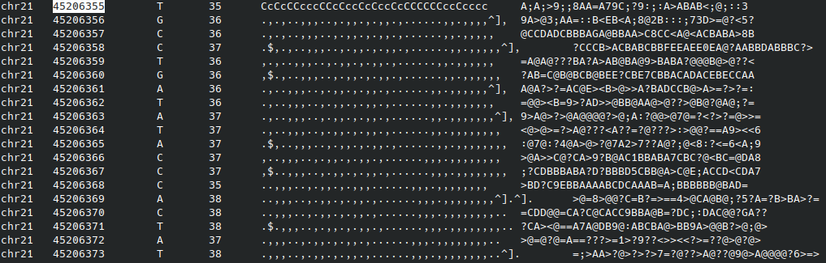

여기서 '.'와 ','는 참조서열과 일치한다는 의미로 쓰임. 즉, pileup format은 개체의 변이 정보를 visually 찾아보는데 매우 효과적이다.

다시 '/'를 누르고 45208636 위치를 찾아보자.

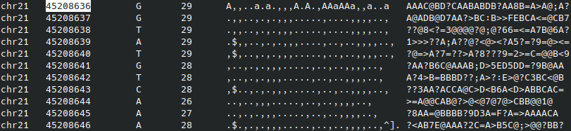

이것을 해석해보면 "chr21:45208636 위치의 reference genome sequence는 G이고, 이 locus에 29개의 reads가 mapped 되어있는데, 그 값은 A/G 모두 나타났다. 즉, heterozygous A/G인 것이다."

**BAM 파일을 BED 포맷으로 변경해보자.** BED 포맷은 화면 표시를 위한 포맷을 많이 쓰인다. UCSC Genome Browser 트랙에 custom track을 추가하여 보고자 할 때 BED 포맷을 사용한다.

```bash
bamToBed -i aligned.bam > out.bed
```

```
Command 'bamToBed' not found, but can be installed with:

sudo apt install bedtools
```

Bedtools가 설치되어있지 않다. `conda install bedtools`로 설치.

그리고 나서 conda environment를 실행시킨 뒤 다시 bam 디렉토리로 들어가서 실행한다.

```bash
conda activate conda-env
```

```
(conda-env)
```

```bash
pwd
```

```
/home/seungho/GDA/NGS/NGSFormat
(conda-env)
```

```bash
cd bam
```

```
(conda-env)
```

```bash
bamToBed -i aligned.bam > out.bed
```

```
(conda-env)
```

```bash
ls
```

```
aligned.bam  aligned.bam.bai  aligned.sam  out.bam  out.bed  out.pileup
(conda-env)
```

```bash
head out.bed
```

```
chr21	9497414	9497514	SDUS-BRUNO-015B_775:2:1308:1344:108111/1	25	-
chr21	9595178	9595278	SDUS-BRUNO-015B_775:2:1106:9117:173634/2	37	+
chr21	9647443	9647543	SDUS-BRUNO-015B_775:4:2208:4615:154306/2	25	+
chr21	9696693	9696793	SDUS-BRUNO-015B_775:2:2307:14497:114310/2	37	-
chr21	9961219	9961318	SDUS-BRUNO-015B_775:3:2102:4832:112349/2	37	-
chr21	10024787	10024887	SDUS-BRUNO-015B_775:2:1304:17225:145079/1	0	+
chr21	10096052	10096152	SDUS-BRUNO-015B_775:4:2202:6273:68988/1	37	-
chr21	10731857	10731957	SDUS-BRUNO-015B_775:3:1104:17232:80111/2	25	-
chr21	10768425	10768525	SDUS-BRUNO-015B_775:3:2105:5624:88623/2	0	+
chr21	10887535	10887635	SDUS-BRUNO-015B_775:4:2304:3841:162909/2	37	+
(conda-env)
```

**이번엔 BAM 파일을 BCF로 바꾸어 보자.** *BCF* 포맷은 우리가 많이 사용하는 *VCF* 파일의 이진 파일 폼이다. 명령어에서 알 수 있듯이 pileup 포맷을 거쳐간다. 즉 locus 별로 어떤 염기가 삭제되었는지 보고해주는 것으로 생각하면 된다. samtools와 bcftools가 main에 설치되어있기 때문에 main을 이용하기 위해 `conda deactivate`을 한다.

```bash
conda deactivate
```

```
(base)
```

```bash
samtools mpileup -uf ../fasta/chr21.fa aligned.bam | bcftools view - > out.bcf
```

```
[warning] samtools mpileup option `u` is functional, but deprecated. Please switch to using bcftools mpileup in future.
[mpileup] 1 samples in 1 input files
(base)
```

```bash
ls -la | grep out.bcf
```

```
-rw-rw-r-- 1 seungho seungho 142812972  7월 15 15:02 out.bcf
(base)
```

```bash
head -5 out.bcf
```

```
##fileformat=VCFv4.2
##FILTER=<ID=PASS,Description="All filters passed">
##samtoolsVersion=1.9+htslib-1.9
##samtoolsCommand=samtools mpileup -uf ../fasta/chr21.fa aligned.bam
##reference=file://../fasta/chr21.fa
(base)
```

```bash
head -10 out.bcf
```

```
##fileformat=VCFv4.2
##FILTER=<ID=PASS,Description="All filters passed">
##samtoolsVersion=1.9+htslib-1.9
##samtoolsCommand=samtools mpileup -uf ../fasta/chr21.fa aligned.bam
##reference=file://../fasta/chr21.fa
##contig=<ID=chr21,length=48129895>
##ALT=<ID=*,Description="Represents allele(s) other than observed.">
##INFO=<ID=INDEL,Number=0,Type=Flag,Description="Indicates that the variant is an INDEL.">
##INFO=<ID=IDV,Number=1,Type=Integer,Description="Maximum number of reads supporting an indel">
##INFO=<ID=IMF,Number=1,Type=Float,Description="Maximum fraction of reads supporting an indel">
(base)
```

이진 포맷으로 읽을 수 없어야되긴 하는데... 왜인지 읽을 수 있다. 왜지?

이유를 알았다. bcftools view의 옵션 중 -O (output file의 타입)에 의해 binary 형태로 지정할 수 있다. http://samtools.github.io/bcftools/bcftools.html#view 참고.

그러면 `bcftools view -O b`로 설정하면 된다.

다시하자.

```bash
samtools mpileup -uf ../fasta/chr21.fa aligned.bam | bcftools view -O b > out.bcf
```

```
[warning] samtools mpileup option `u` is functional, but deprecated. Please switch to using bcftools mpileup in future.
[mpileup] 1 samples in 1 input files
(base)
```

```bash
head -10 out.bcf
```

[output not shown]

올바르게 binary 형태로 나왔으며 사람이 읽을 수 없는 형태임을 확인할 수 있다. 용량을 살펴보면

```bash
ls -la | grep out.bcf
```

```
-rw-rw-r-- 1 seungho seungho  27040400  7월 15 15:22 out.bcf
(base)
```

이다.

```bash
bcftools view out.bcf > out.vcf
```

```
(base)
```

```bash
head -10 out.vcf
```

```
##fileformat=VCFv4.2
##FILTER=<ID=PASS,Description="All filters passed">
##samtoolsVersion=1.9+htslib-1.9
##samtoolsCommand=samtools mpileup -uf ../fasta/chr21.fa aligned.bam
##reference=file://../fasta/chr21.fa
##contig=<ID=chr21,length=48129895>
##ALT=<ID=*,Description="Represents allele(s) other than observed.">
##INFO=<ID=INDEL,Number=0,Type=Flag,Description="Indicates that the variant is an INDEL.">
##INFO=<ID=IDV,Number=1,Type=Integer,Description="Maximum number of reads supporting an indel">
##INFO=<ID=IMF,Number=1,Type=Float,Description="Maximum fraction of reads supporting an indel">
(base)
```

```bash
ls -la | grep out.vcf
```

```
-rw-rw-r-- 1 seungho seungho 142813042  7월 15 15:23 out.vcf
(base)
```

vcf 형식의 용량을 보면 약 5배 정도 큰 것을 알 수 있다.

# VCF 포맷

## VCF 파일 압축과 색인 생성

한 명의 vcf파일은 용량이 그렇게 크지 않지만, 1000 Genome Projects에서 다운 받는 파일은 2504명 분의 데이터가 들어있으므로 일반적인 메모장 프로그램에서 열기 힘들다. 열람할 수 있더라도 그렇게 큰 데이터를 메모리에 올려서 다루기는 매우 까다롭다. 그러므로 큰 VCF 파일은 compression을 통하여 효율적으로 다룰 수 있어야 하며 compressed된 상태에서도 파일의 열람이 가능해야 한다.

```bash
cd ~/GDA/NGS/NGSFormat/vcf
```

```
(base)
```

```bash
pwd
```

```
/home/seungho/GDA/NGS/NGSFormat/vcf
(base)
```

압축

```bash
bgzip -c dbsnp132.vcf > dbsnp132.vcf.gz
```

```
(base)
```

```bash
ll
```

```
합계 4328
drwxrwxr-x 2 seungho seungho    4096  7월 15 15:31 ./
drwxrwxr-x 7 seungho seungho    4096  7월 15 15:31 ../
-rw-rw-r-- 1 seungho seungho 3826841  7월 14 19:22 dbsnp132.vcf
-rw-rw-r-- 1 seungho seungho  563151  7월 15 15:31 dbsnp132.vcf.gz
-rw-rw-r-- 1 seungho seungho   11265  7월 14 19:22 sample1.vcf
-rw-rw-r-- 1 seungho seungho   12505  7월 14 19:22 sample2.vcf
(base)
```

이게 압축된 데이터를 열람할 수 있도록 색인생성을 하고, 원하는 영역을 지정해주면 해당 데이터를 볼 수 있다. 그 출력을 파일로 저장하고 싶다면 `> outfile.vcf`를 명령어 뒤에 추가해 주면 된다. 단, VCF 파일은 반드시 헤더 정보가 있어야 하므로 -h 옵션을 넣어주어야 또 다른 VCF파일을 만들 수 있다. 이렇게 압축 파일에 색인 생성을 한 뒤 subset하면 더이상 대용량의 데이터를 다루지 않아도 원하는 영역의 데이터만 자유자재로 뽑아서 다룰 수 있다.

```bash
tabix -p vcf dbsnp132.vcf.gz
```

```
(base)
```

```bash
ll
```

```
합계 4332
drwxrwxr-x 2 seungho seungho    4096  7월 15 15:48 ./
drwxrwxr-x 7 seungho seungho    4096  7월 15 15:47 ../
-rw-rw-r-- 1 seungho seungho 3826841  7월 14 19:22 dbsnp132.vcf
-rw-rw-r-- 1 seungho seungho  563151  7월 15 15:31 dbsnp132.vcf.gz
-rw-rw-r-- 1 seungho seungho    1335  7월 15 15:48 dbsnp132.vcf.gz.tbi
-rw-rw-r-- 1 seungho seungho   11265  7월 14 19:22 sample1.vcf
-rw-rw-r-- 1 seungho seungho   12505  7월 14 19:22 sample2.vcf
(base)
```

```bash
tabix dbsnp132.vcf.gz chr21:44000000-44000100
```

```
chr21	44000052	rs380152	A	G	.	PASS	G5;GMAF=0.398251192368839;GNO;HD;INT;KGPilot123;PH2;RSPOS=44000052;SAO=0;SCS=0;SLO;SSR=0;VC=SNP;VLD;VP=050100080001050512000100;WGT=1;dbSNPBuildID=80
chr21	44000063	rs380161	T	G	.	PASS	G5;GMAF=0.485691573926868;GNO;HD;INT;KGPilot1;KGPilot123;PH2;RSPOS=44000063;SAO=0;SCS=0;SLO;SSR=0;VC=SNP;VLD;VP=05010008000105051a000100;WGT=1;dbSNPBuildID=80
chr21	44000078	rs453647	T	C	.	PASS	G5;GMAF=0.487281399046105;GNO;HD;INT;KGPilot1;KGPilot123;PH2;RSPOS=44000078;SAO=0;SCS=0;SLO;SSR=0;VC=SNP;VLD;VP=05010008000105051a000100;WGT=1;dbSNPBuildID=80
(base)
```

이렇게 vcf 파일에서 chromosome 21, 위치 44000000-44000100 사이에서 reference와 다른 모든 variant allele을 알려준다.

## VCF 파일에서 대립유전자 빈도 구하기 (allele frequency)

1000 Genomes Project 데이터에서 specific region의 allele frequency를 간단한 명령어로 구할 수 있다. 인터넷 연결이 필요하다.

```bash
tabix -fh ftp://ftp.1000genomes.ebi.ac.uk/vol1/ftp/release/20100804/ALL.2of4intersection.20100804.genotypes.vcf.gz 16:57000000-57001000 > genotypes.vcf
```

```
(base)
```

tabix (force: index 파일 있으면 forced overwrite), header-included. 여기의 vcf.gz (압축된 vcf 파일)에서 chromosome 16의 570000000~57001000 사이의 variant 정보를 뽑아온다. 그것을 genotypes.vcf에 저장한다. [tabix manual](http://www.htslib.org/doc/tabix.html) 참조.

```bash
vcftools --vcf genotypes.vcf --freq --out allelefrequencies
```

```
VCFtools - 0.1.15
(C) Adam Auton and Anthony Marcketta 2009

Parameters as interpreted:
	--vcf genotypes.vcf
	--freq
	--out allelefrequencies

After filtering, kept 629 out of 629 Individuals
Outputting Frequency Statistics...
After filtering, kept 15 out of a possible 15 Sites
Run Time = 0.00 seconds
(base)
```

vcftools 를 돌리는데 input으로 들어오는 vcf 파일 이름은 `--vcf genotypes.vcf`, `--freq` 옵션으로 allele frequency를 뽑아낸다는 것을 알려주고 `--out` 옵션으로 output 파일의 이름을 지정한다. 그러면 해당 이름의 `.frq` extension을 갖는 파일이 생성.

```bash
more allelefrequencies.frq
```

```
CHROM	POS	N_ALLELES	N_CHR	{ALLELE:FREQ}
16	57000145	2	1258	C:0.958665	T:0.0413355
16	57000191	2	0	A:-nan	G:-nan
16	57000209	2	348	C:0.951149	A:0.0488506
16	57000212	2	354	G:0.997175	A:0.00282486
16	57000221	2	1258	C:0.988871	T:0.0111288
16	57000242	2	736	A:0.972826	G:0.0271739
16	57000276	2	388	T:0.966495	A:0.0335052
16	57000284	2	1258	G:0.389507	A:0.610493
16	57000336	2	0	A:-nan	G:-nan
16	57000397	2	348	G:0.962644	A:0.0373563
16	57000571	2	334	G:0.994012	A:0.00598802
16	57000626	2	566	C:0.991166	T:0.00883392
16	57000696	2	1258	T:0.99682	A:0.00317965
16	57000885	2	1258	G:0.749603	A:0.250397
16	57000938	2	1258	G:0.929253	A:0.0707472
(base)
```

## VCF 파일에서 원하는 샘플 데이터 추출하기

1000 Genomes Project에서 다운받은 데이터에는 2500여명 분의 데이터가 담겨있다고 앞서 설명했다. 원하는 샘플만 하나의 파일에 따로 저장하고 싶을 때가 있다면 다음의 명령어를 이용하여 추출할 수 있다. 앞서 받아서 저장한 `genotypes.vcf` 파일에서 HG00098 샘플의 데이터를 추출해보자.

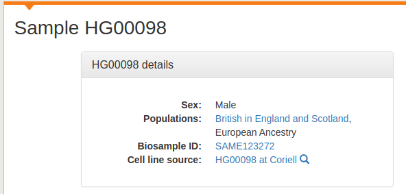

유러피안 ancestry인 영국 남성 한 명의 데이터이다.

```bash
vcf-subset -c HG00098 genotypes.vcf > HG00098.vcf #HG00098을 subset하라, genotypes.vcf에서. 그리고 그것을 HG00098.vcf로 출력하라.
```

```
(base)
```

```bash
more HG00098.vcf
```

```
##fileformat=VCFv4.0
##filedat=20101112
##datarelease=20100804
##samples=629
##description="Where BI calls are present, genotypes and alleles are from BI.  I
n there absence, UM genotypes are used.  If neither are available, no genotype i
nformation is present and the alleles are from the NCBI calls."
##FORMAT=<ID=AD,Number=.,Type=Integer,Description="Allelic depths for the ref an
d alt alleles in the order listed">
##FORMAT=<ID=DP,Number=1,Type=Integer,Description="Read Depth (only filtered rea
ds used for calling)">
##FORMAT=<ID=GL,Number=3,Type=Float,Description="Log-scaled likelihoods for AA,A
B,BB genotypes where A=ref and B=alt; not applicable if site is not biallelic">
##FORMAT=<ID=GQ,Number=1,Type=Float,Description="Genotype Quality">
##FORMAT=<ID=GT,Number=1,Type=String,Description="Genotype">
##FORMAT=<ID=GD,Number=1,Type=Float,Description="Genotype dosage.  Expected coun
t of non-ref alleles [0,2]">
##FORMAT=<ID=OG,Number=1,Type=String,Description="Original Genotype input to Bea
gle">
##INFO=<ID=AF,Number=.,Type=Float,Description="Allele Frequency, for each ALT al
lele, in the same order as listed">
##INFO=<ID=DP,Number=1,Type=Integer,Description="Total Depth">
##INFO=<ID=CB,Number=.,Type=String,Description="List of centres that called, UM
(base) --(46%)
```

## VCF 파일 비교

두 명 이상의 샘플에 대한 VCF 파일이 있다면, 각각의 variant 개수 등을 비교할 수 있다. 두 명의 sample에 대한 VCF 파일을 비교하는데는 압축 -> 색인 생성 까지 같고, 그 뒤 `vcf-compare sample1.vcf.gz sample2.vcf.gz`를 한다.

```bash
bgzip sample1.vcf
```

```
(base)
```

```bash
bgzip sample2.vcf
```

```
(base)
```

```bash
tabix -p vcf sample1.vcf.gz
tabix -p vcf sample2.vcf.gz
```

```
(base) (base)
```

```bash
vcf-compare sample1.vcf.gz sample2.vcf.gz
```

```
# This file was generated by vcf-compare.
# The command line was: vcf-compare(v0.1.14-12-gcdb80b8) sample1.vcf.gz sample2.vcf.gz
#
#VN 'Venn-Diagram Numbers'. Use `grep ^VN | cut -f 2-` to extract this part.
#VN The columns are:
#VN        1  .. number of sites unique to this particular combination of files
#VN        2- .. combination of files and space-separated number, a fraction of sites in the file
VN	35	sample1.vcf.gz (43.8%)
VN	45	sample1.vcf.gz (56.2%)	sample2.vcf.gz (48.9%)
VN	47	sample2.vcf.gz (51.1%)
#SN Summary Numbers. Use `grep ^SN | cut -f 2-` to extract this part.
SN	Number of REF matches:	45
SN	Number of ALT matches:	45
SN	Number of REF mismatches:	0
SN	Number of ALT mismatches:	0
SN	Number of samples in GT comparison:	0
(base)
```

Sample 1과 Sample2에서 동시에 발견된 variant는 45개 (각각의 56.2%, 48.9%를 차지한다) 이고, Sample1 에서만 발견된 변이는 35개 (43.8% of Sample1), Sample2 에서만 발견된 변이는 47개 (51.1% of Sample2)이다.

# Visualization Tools

## IGV viewer (Integrative Genomics Viewer)

대표적으로 가장 많이 사용하는 염기서열 시각화 도구는 IGV이다. IGV를 사용하기 위해서는 BAM 파일이 인덱싱되어 있어야 하므로 SAMtools를 사용하여 indexing하여 `.bam.bai` extension 파일을 만든 다음 IGV를 실행하자.

```bash
cd ../bam
```

```
(base)
```

```bash
ll
```

```
합계 542160
drwxrwxr-x 2 seungho seungho      4096  7월 15 15:06 ./
drwxrwxr-x 7 seungho seungho      4096  7월 15 16:21 ../
-rw-rw-r-- 1 seungho seungho  52233665  7월 14 19:22 aligned.bam
-rw-rw-r-- 1 seungho seungho     28424  7월 14 19:22 aligned.bam.bai
-rw-rw-r-- 1 seungho seungho 167384793  7월 15 10:38 aligned.sam
-rw-rw-r-- 1 seungho seungho  51867268  7월 15 11:08 out.bam
-rw-rw-r-- 1 seungho seungho  27040400  7월 15 15:22 out.bcf
-rw-rw-r-- 1 seungho seungho  24154793  7월 15 14:40 out.bed
-rw-rw-r-- 1 seungho seungho  89616907  7월 15 11:14 out.pileup
-rw-rw-r-- 1 seungho seungho 142813042  7월 15 15:23 out.vcf
(base)
```

```bash
samtools index aligned.bam
```

```
(base)
```

```bash
ls -la | grep *.bai
```

```
-rw-rw-r-- 1 seungho seungho     28424  7월 15 16:22 aligned.bam.bai
(base)
```

```bash
igv
```

여기엔 igv가 설치되어있지 않지만, 서버에서 실행했다. (X manager를 통해 gnome을 virtual screen으로 불러올 수 있었다.)

그 다음 Human hg19을 기준으로 align 되었으므로 Human hg19을 선택하고, File->Load from File에서 `aligned.bam`을 load한다.

다음은 서버에서 실행한 결과를 캡처한 것이다.

1. Reference genome인 hg19을 기준으로 설정.

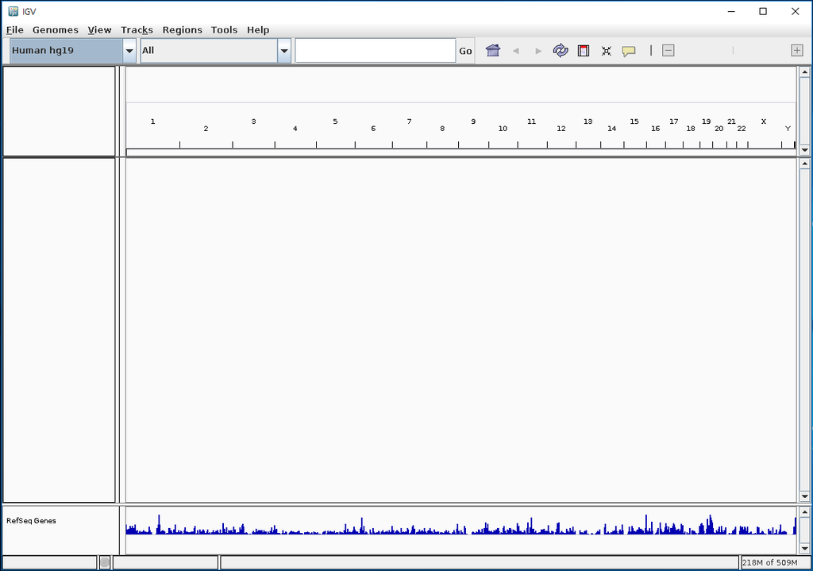

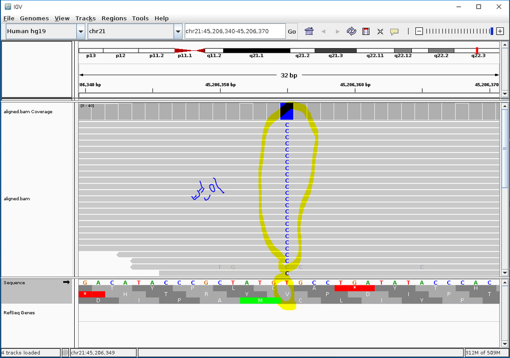

1. Absolute position 뿐 아니라 EGFR 등의 gene name으로도 browsing 할 수 있다. 다음은 `AIRE`를 검색한 화면. 아래쪽에 RefSeq Genes 서열과 exon/intron 구조가 나타나면서 유전자 전체를 보여주고, 위쪽 분할화면에는 aligned reads의 정렬 상태를 보여준다.

[figure not shown]

## SAMtools Text Alignment Viewer

IGV가 나오기 전에는 대부분 SAMtools에서 제공하는 TView를 이용했다. 명령어는

`samtools tview aligned.bam ../fasta/chr21.fa`로 samtools tview [bam파일] [reference 파일] 형태이다.

```bash
pwd
```

```
/home/seungho/GDA/NGS/NGSFormat/bam
(base)
```

```bash
samtools tview aligned.bam ../fasta/chr21.fa
```

[output not shown]

노트북에서는 보이지 않으므로 실제 실행 화면은 다음과 같다. `g` (Go의 단축키)를 누르고 `chr21:45206355` 와 같이 chromosome과 position을 지정해 주면 해당 base로 이동한다. pileup과 같은 포맷을 사용하고 있음을 확인할 수 있다. '.'과','는 모두 일치함을 나타내며, 알파벳은 aligned read에서 나타나는 변이이다.

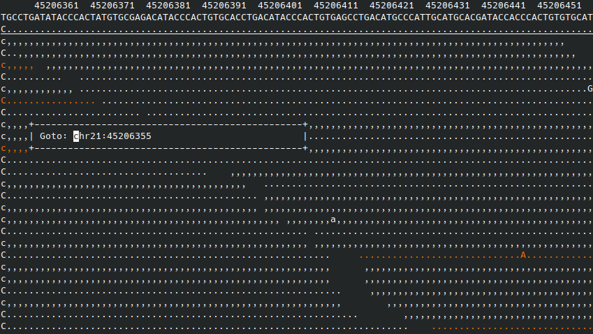

`r` 눌렀을 때: Position마다 read의 정보가 나타남

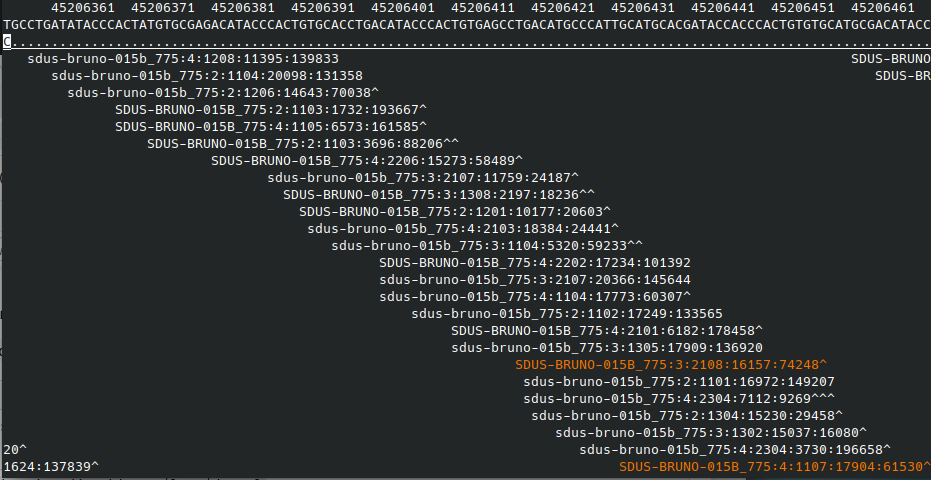

`n` 눌렀을 때: 색으로 position 구분이 쉬워진다.

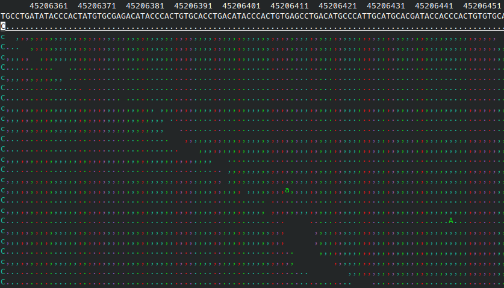

TView를 실행할 때 참조유전체 (reference genome)을 지정해주지 않으면 맨 윗 줄에 NNNNNN...으로 표시되고 리드의 염기를 모두 보여준다.